# Ford GoBike Data Exploration

## Preliminary Wrangling

This document explores a dataset containing data about Ford GoBike Trips.

```python
# import all packages and set plots to be embedded inline
import numpy as np
import pandas as pd
import matplotlib.pyplot as plt
import seaborn as sb

%matplotlib inline

import warnings
warnings.simplefilter("ignore")
```

```python
# load in the dataset into a pandas dataframe (df), print statistics
df = pd.read_csv('201902-fordgobike-tripdata.csv')
```

```python
df.head(5)
```

|  | duration_sec | start_time | end_time | start_station_id | start_station_name | start_station_latitude | start_station_longitude | end_station_id | end_station_name | end_station_latitude | end_station_longitude | bike_id | user_type | member_birth_year | member_gender | bike_share_for_all_trip |
| --- | --- | --- | --- | --- | --- | --- | --- | --- | --- | --- | --- | --- | --- | --- | --- | --- |
| 0 | 52185 | 2019-02-28 17:32:10.1450 | 2019-03-01 08:01:55.9750 | 21.0 | Montgomery St BART Station (Market St at 2nd St) | 37.789625 | -122.400811 | 13.0 | Commercial St at Montgomery St | 37.794231 | -122.402923 | 4902 | Customer | 1984.0 | Male | No |
| 1 | 42521 | 2019-02-28 18:53:21.7890 | 2019-03-01 06:42:03.0560 | 23.0 | The Embarcadero at Steuart St | 37.791464 | -122.391034 | 81.0 | Berry St at 4th St | 37.775880 | -122.393170 | 2535 | Customer | NaN | NaN | No |
| 2 | 61854 | 2019-02-28 12:13:13.2180 | 2019-03-01 05:24:08.1460 | 86.0 | Market St at Dolores St | 37.769305 | -122.426826 | 3.0 | Powell St BART Station (Market St at 4th St) | 37.786375 | -122.404904 | 5905 | Customer | 1972.0 | Male | No |
| 3 | 36490 | 2019-02-28 17:54:26.0100 | 2019-03-01 04:02:36.8420 | 375.0 | Grove St at Masonic Ave | 37.774836 | -122.446546 | 70.0 | Central Ave at Fell St | 37.773311 | -122.444293 | 6638 | Subscriber | 1989.0 | Other | No |
| 4 | 1585 | 2019-02-28 23:54:18.5490 | 2019-03-01 00:20:44.0740 | 7.0 | Frank H Ogawa Plaza | 37.804562 | -122.271738 | 222.0 | 10th Ave at E 15th St | 37.792714 | -122.248780 | 4898 | Subscriber | 1974.0 | Male | Yes |

```python
# high-level overview of data shape and composition
print(df.shape)
print(df.dtypes)
print(df.head(10))
```

```
(183412, 16)
duration_sec                 int64
start_time                  object
end_time                    object
start_station_id           float64
start_station_name          object
start_station_latitude     float64
start_station_longitude    float64
end_station_id             float64
end_station_name            object
end_station_latitude       float64
end_station_longitude      float64
bike_id                      int64
user_type                   object
member_birth_year          float64
member_gender               object
bike_share_for_all_trip     object
dtype: object
   duration_sec                start_time                  end_time  \
0         52185  2019-02-28 17:32:10.1450  2019-03-01 08:01:55.9750
1         42521  2019-02-28 18:53:21.7890  2019-03-01 06:42:03.0560
2         61854  2019-02-28 12:13:13.2180  2019-03-01 05:24:08.1460
3         36490  2019-02-28 17:54:26.0100  2019-03-01 04:02:36.8420
4          1585  2019-02-28 23:54:18.5490  2019-03-01 00:20:44.0740
5          1793  2019-02-28 23:49:58.6320  2019-03-01 00:19:51.7600
6          1147  2019-02-28 23:55:35.1040  2019-03-01 00:14:42.5880
7          1615  2019-02-28 23:41:06.7660  2019-03-01 00:08:02.7560
8          1570  2019-02-28 23:41:48.7900  2019-03-01 00:07:59.7150
9          1049  2019-02-28 23:49:47.6990  2019-03-01 00:07:17.0250

   start_station_id                                start_station_name  \
0              21.0  Montgomery St BART Station (Market St at 2nd St)
1              23.0                     The Embarcadero at Steuart St
2              86.0                           Market St at Dolores St
3             375.0                           Grove St at Masonic Ave
4               7.0                               Frank H Ogawa Plaza
5              93.0                      4th St at Mission Bay Blvd S
6             300.0                              Palm St at Willow St
7              10.0                        Washington St at Kearny St
8              10.0                        Washington St at Kearny St
```

[output cut: 34 more lines]

```
7            -122.421025     6329  Subscriber             1989.0
8            -122.421025     6548  Subscriber             1988.0
9            -122.421339     6488  Subscriber             1992.0

  member_gender bike_share_for_all_trip
0          Male                      No
1           NaN                      No
2          Male                      No
3         Other                      No
4          Male                     Yes
5          Male                      No
6        Female                      No
7          Male                      No
8         Other                      No
9          Male                      No
```

```python
df.describe()
```

|  | duration_sec | start_station_id | start_station_latitude | start_station_longitude | end_station_id | end_station_latitude | end_station_longitude | bike_id | member_birth_year |
| --- | --- | --- | --- | --- | --- | --- | --- | --- | --- |
| count | 183412.000000 | 183215.000000 | 183412.000000 | 183412.000000 | 183215.000000 | 183412.000000 | 183412.000000 | 183412.000000 | 175147.000000 |
| mean | 726.078435 | 138.590427 | 37.771223 | -122.352664 | 136.249123 | 37.771427 | -122.352250 | 4472.906375 | 1984.806437 |
| std | 1794.389780 | 111.778864 | 0.099581 | 0.117097 | 111.515131 | 0.099490 | 0.116673 | 1664.383394 | 10.116689 |
| min | 61.000000 | 3.000000 | 37.317298 | -122.453704 | 3.000000 | 37.317298 | -122.453704 | 11.000000 | 1878.000000 |
| 25% | 325.000000 | 47.000000 | 37.770083 | -122.412408 | 44.000000 | 37.770407 | -122.411726 | 3777.000000 | 1980.000000 |
| 50% | 514.000000 | 104.000000 | 37.780760 | -122.398285 | 100.000000 | 37.781010 | -122.398279 | 4958.000000 | 1987.000000 |
| 75% | 796.000000 | 239.000000 | 37.797280 | -122.286533 | 235.000000 | 37.797320 | -122.288045 | 5502.000000 | 1992.000000 |
| max | 85444.000000 | 398.000000 | 37.880222 | -121.874119 | 398.000000 | 37.880222 | -121.874119 | 6645.000000 | 2001.000000 |

```python
df.info()
```

```
<class 'pandas.core.frame.DataFrame'>
RangeIndex: 183412 entries, 0 to 183411
Data columns (total 16 columns):
 #   Column                   Non-Null Count   Dtype
---  ------                   --------------   -----
 0   duration_sec             183412 non-null  int64
 1   start_time               183412 non-null  object
 2   end_time                 183412 non-null  object
 3   start_station_id         183215 non-null  float64
 4   start_station_name       183215 non-null  object
 5   start_station_latitude   183412 non-null  float64
 6   start_station_longitude  183412 non-null  float64
 7   end_station_id           183215 non-null  float64
 8   end_station_name         183215 non-null  object
 9   end_station_latitude     183412 non-null  float64
 10  end_station_longitude    183412 non-null  float64
 11  bike_id                  183412 non-null  int64
 12  user_type                183412 non-null  object
 13  member_birth_year        175147 non-null  float64
 14  member_gender            175147 non-null  object
 15  bike_share_for_all_trip  183412 non-null  object
dtypes: float64(7), int64(2), object(7)
memory usage: 22.4+ MB
```

## Data Cleaning

```python
# Check for nulls
df.isna().sum()
```

```
duration_sec                  0
start_time                    0
end_time                      0
start_station_id            197
start_station_name          197
start_station_latitude        0
start_station_longitude       0
end_station_id              197
end_station_name            197
end_station_latitude          0
end_station_longitude         0
bike_id                       0
user_type                     0
member_birth_year          8265
member_gender              8265
bike_share_for_all_trip       0
dtype: int64
```

```python
#There are 197 empty station IDs/ Names
df.start_station_id.isna().sum()

#Trying to find out a way to fill the empty IDs, using the latitdue and longitdue
df[df.start_station_id.isna()].start_station_latitude

df[df.end_station_latitude.isin(df[df.end_station_id.isna()].end_station_latitude) ]
```

|  | duration_sec | start_time | end_time | start_station_id | start_station_name | start_station_latitude | start_station_longitude | end_station_id | end_station_name | end_station_latitude | end_station_longitude | bike_id | user_type | member_birth_year | member_gender | bike_share_for_all_trip |
| --- | --- | --- | --- | --- | --- | --- | --- | --- | --- | --- | --- | --- | --- | --- | --- | --- |
| 475 | 1709 | 2019-02-28 20:55:53.9320 | 2019-02-28 21:24:23.7380 | NaN | NaN | 37.40 | -121.94 | NaN | NaN | 37.40 | -121.93 | 4211 | Customer | 1991.0 | Female | No |
| 1733 | 1272 | 2019-02-28 18:32:34.2730 | 2019-02-28 18:53:46.7270 | NaN | NaN | 37.40 | -121.94 | NaN | NaN | 37.41 | -121.96 | 4174 | Subscriber | 1980.0 | Male | No |
| 3625 | 142 | 2019-02-28 17:10:46.5290 | 2019-02-28 17:13:09.4310 | NaN | NaN | 37.41 | -121.95 | NaN | NaN | 37.41 | -121.96 | 4283 | Subscriber | 1988.0 | Male | No |
| 4070 | 585 | 2019-02-28 16:28:45.9340 | 2019-02-28 16:38:31.3320 | NaN | NaN | 37.39 | -121.93 | NaN | NaN | 37.40 | -121.92 | 4089 | Subscriber | 1984.0 | Male | Yes |
| 5654 | 509 | 2019-02-28 12:30:17.1310 | 2019-02-28 12:38:46.3290 | NaN | NaN | 37.40 | -121.92 | NaN | NaN | 37.39 | -121.93 | 4089 | Subscriber | 1984.0 | Male | Yes |
| ... | ... | ... | ... | ... | ... | ... | ... | ... | ... | ... | ... | ... | ... | ... | ... | ... |
| 176154 | 1447 | 2019-02-02 12:03:04.5440 | 2019-02-02 12:27:12.2670 | NaN | NaN | 37.40 | -121.93 | NaN | NaN | 37.40 | -121.93 | 4249 | Customer | 1984.0 | Male | No |
| 179730 | 309 | 2019-02-01 12:59:45.9690 | 2019-02-01 13:04:55.4260 | NaN | NaN | 37.40 | -121.94 | NaN | NaN | 37.40 | -121.93 | 4249 | Customer | 1987.0 | Female | No |
| 179970 | 659 | 2019-02-01 12:17:37.6750 | 2019-02-01 12:28:37.0140 | NaN | NaN | 37.41 | -121.96 | NaN | NaN | 37.41 | -121.94 | 4092 | Subscriber | 1999.0 | Female | No |
| 180106 | 2013 | 2019-02-01 11:33:55.1470 | 2019-02-01 12:07:28.9400 | NaN | NaN | 37.40 | -121.94 | NaN | NaN | 37.40 | -121.94 | 4251 | Customer | 1990.0 | Female | No |
| 181201 | 312 | 2019-02-01 09:26:34.8030 | 2019-02-01 09:31:46.9210 | NaN | NaN | 37.40 | -121.93 | NaN | NaN | 37.40 | -121.93 | 4208 | Subscriber | 1987.0 | Male | No |

197 rows × 16 columns

> Even using the latitdue & longitude will not help identifying the missing station IDs.

```python
# Checking if the trips with empty member birth year have also empty member gender
df[df.member_birth_year.isna()& ~df.member_gender.isna()]
```

|  | duration_sec | start_time | end_time | start_station_id | start_station_name | start_station_latitude | start_station_longitude | end_station_id | end_station_name | end_station_latitude | end_station_longitude | bike_id | user_type | member_birth_year | member_gender | bike_share_for_all_trip |
| --- | --- | --- | --- | --- | --- | --- | --- | --- | --- | --- | --- | --- | --- | --- | --- | --- |

> Some trips have no member information.

```python
# checking the percentage of trips without member information
df.member_birth_year.isna().sum()/df.shape[0] * 100
```

```
4.506248228033062
```

> With percentage of only 4.5% with no memeber information

```python
# drop those na values

df.dropna(inplace=True, subset=['member_birth_year'])

df.dropna(inplace=True, subset=['start_station_id'])
```

> The memeber information is missing for 8265 memebers

```python
# Making sure we have no trips with empty member information
df.member_birth_year.isna().sum()/df.shape[0] * 100
```

```
0.0
```

```python
## Check for dupliates

df.duplicated().sum()
```

```
0
```

> No duplicates found

### Changing the data types

```python
df.info()
```

```
<class 'pandas.core.frame.DataFrame'>
Int64Index: 174952 entries, 0 to 183411
Data columns (total 16 columns):
 #   Column                   Non-Null Count   Dtype
---  ------                   --------------   -----
 0   duration_sec             174952 non-null  int64
 1   start_time               174952 non-null  object
 2   end_time                 174952 non-null  object
 3   start_station_id         174952 non-null  float64
 4   start_station_name       174952 non-null  object
 5   start_station_latitude   174952 non-null  float64
 6   start_station_longitude  174952 non-null  float64
 7   end_station_id           174952 non-null  float64
 8   end_station_name         174952 non-null  object
 9   end_station_latitude     174952 non-null  float64
 10  end_station_longitude    174952 non-null  float64
 11  bike_id                  174952 non-null  int64
 12  user_type                174952 non-null  object
 13  member_birth_year        174952 non-null  float64
 14  member_gender            174952 non-null  object
 15  bike_share_for_all_trip  174952 non-null  object
dtypes: float64(7), int64(2), object(7)
memory usage: 22.7+ MB
```

```python
# adjust the data types

## change the string of start time & end time to datetimes

df['start_time'] = df.start_time.astype('datetime64[ns]')

df['end_time'] = df.end_time.astype('datetime64[ns]')

## change the floating member_birth_year and stations IDs to int
df['member_birth_year'] = df.member_birth_year.astype('int32')

df['start_station_id'] = df.start_station_id.astype('int32')

df['end_station_id'] = df.end_station_id.astype('int32')

df.head()
```

|  | duration_sec | start_time | end_time | start_station_id | start_station_name | start_station_latitude | start_station_longitude | end_station_id | end_station_name | end_station_latitude | end_station_longitude | bike_id | user_type | member_birth_year | member_gender | bike_share_for_all_trip |
| --- | --- | --- | --- | --- | --- | --- | --- | --- | --- | --- | --- | --- | --- | --- | --- | --- |
| 0 | 52185 | 2019-02-28 17:32:10.145 | 2019-03-01 08:01:55.975 | 21 | Montgomery St BART Station (Market St at 2nd St) | 37.789625 | -122.400811 | 13 | Commercial St at Montgomery St | 37.794231 | -122.402923 | 4902 | Customer | 1984 | Male | No |
| 2 | 61854 | 2019-02-28 12:13:13.218 | 2019-03-01 05:24:08.146 | 86 | Market St at Dolores St | 37.769305 | -122.426826 | 3 | Powell St BART Station (Market St at 4th St) | 37.786375 | -122.404904 | 5905 | Customer | 1972 | Male | No |
| 3 | 36490 | 2019-02-28 17:54:26.010 | 2019-03-01 04:02:36.842 | 375 | Grove St at Masonic Ave | 37.774836 | -122.446546 | 70 | Central Ave at Fell St | 37.773311 | -122.444293 | 6638 | Subscriber | 1989 | Other | No |
| 4 | 1585 | 2019-02-28 23:54:18.549 | 2019-03-01 00:20:44.074 | 7 | Frank H Ogawa Plaza | 37.804562 | -122.271738 | 222 | 10th Ave at E 15th St | 37.792714 | -122.248780 | 4898 | Subscriber | 1974 | Male | Yes |
| 5 | 1793 | 2019-02-28 23:49:58.632 | 2019-03-01 00:19:51.760 | 93 | 4th St at Mission Bay Blvd S | 37.770407 | -122.391198 | 323 | Broadway at Kearny | 37.798014 | -122.405950 | 5200 | Subscriber | 1959 | Male | No |

### Adding derived columns

```python
# Roll up the duration dimension to the level of the minutes
df['duration_in_mins'] = round(df['duration_sec']/60,2)

# Add new dimension, the member age

from datetime import date

df['member_age'] = int(str(date.today())[:4]) - df['member_birth_year']

# Distribute the age in buckets ranging from younger than 30 years old to older than 70 yeras old.
age_bins= [20,30,40,50,60,70,999]
age_buckets_labels = ['<30','<40','<50','<60', '<70', '>70']
df ['member_age_bucket' ] = pd.cut(df['member_age'], bins = age_bins, labels=age_buckets_labels, right=False)


# The distance can be calculated based on the latitude and longitude of the start and end stations

df['trip_distance'] = np.sqrt((df.start_station_latitude - df.end_station_latitude)**2 + (df.start_station_longitude - df.end_station_longitude)**2 )*100

# Adding the proper order of the weekdays
weekdays_order = ['Monday', 'Tuesday', 'Wednesday', 'Thursday', 'Friday', 'Saturday', 'Sunday']


# Adding some new dimension rolled up from the start time data.
df['trip_start_day']  = df.start_time.dt.day_name()

df['trip_start_hour'] = df.start_time.dt.hour

df.head()
```

|  | duration_sec | start_time | end_time | start_station_id | start_station_name | start_station_latitude | start_station_longitude | end_station_id | end_station_name | end_station_latitude | ... | user_type | member_birth_year | member_gender | bike_share_for_all_trip | duration_in_mins | member_age | member_age_bucket | trip_distance | trip_start_day | trip_start_hour |
| --- | --- | --- | --- | --- | --- | --- | --- | --- | --- | --- | --- | --- | --- | --- | --- | --- | --- | --- | --- | --- | --- |
| 0 | 52185 | 2019-02-28 17:32:10.145 | 2019-03-01 08:01:55.975 | 21 | Montgomery St BART Station (Market St at 2nd St) | 37.789625 | -122.400811 | 13 | Commercial St at Montgomery St | 37.794231 | ... | Customer | 1984 | Male | No | 869.75 | 38 | <40 | 0.506676 | Thursday | 17 |
| 2 | 61854 | 2019-02-28 12:13:13.218 | 2019-03-01 05:24:08.146 | 86 | Market St at Dolores St | 37.769305 | -122.426826 | 3 | Powell St BART Station (Market St at 4th St) | 37.786375 | ... | Customer | 1972 | Male | No | 1030.90 | 50 | <60 | 2.778353 | Thursday | 12 |
| 3 | 36490 | 2019-02-28 17:54:26.010 | 2019-03-01 04:02:36.842 | 375 | Grove St at Masonic Ave | 37.774836 | -122.446546 | 70 | Central Ave at Fell St | 37.773311 | ... | Subscriber | 1989 | Other | No | 608.17 | 33 | <40 | 0.272087 | Thursday | 17 |
| 4 | 1585 | 2019-02-28 23:54:18.549 | 2019-03-01 00:20:44.074 | 7 | Frank H Ogawa Plaza | 37.804562 | -122.271738 | 222 | 10th Ave at E 15th St | 37.792714 | ... | Subscriber | 1974 | Male | Yes | 26.42 | 48 | <50 | 2.583538 | Thursday | 23 |
| 5 | 1793 | 2019-02-28 23:49:58.632 | 2019-03-01 00:19:51.760 | 93 | 4th St at Mission Bay Blvd S | 37.770407 | -122.391198 | 323 | Broadway at Kearny | 37.798014 | ... | Subscriber | 1959 | Male | No | 29.88 | 63 | <70 | 3.130059 | Thursday | 23 |

5 rows × 22 columns

### What is the structure of your dataset?

- Time information
  - `start_time` the time of starting the trip.
  - `end_time` the time of ending the trip.
  - `trip_start_day` the weekday of the trip.
  - `trip_start_hour` the hour of day of the trip.
- Trip Information
  - `start_station_id` the ID of the starting station.
  - `start_station_name` the name of starting station.
  - `start_station_latitude` the latitude of the starting station location.
  - `start_station_longitdue` the longitude of the starting station location.
  - `end_station_id` the ID of the end station.
  - `end_station_name` the name of end station.
  - `end_station_latitude` the latitude of the end station location.
  - `end_station_longitdue` the longitude of the end station location.
  - `duration_sec` the trip duration in seconds.
  - `duration_in_mins` the trip duration in minutes.
  - `trip_distance` the trip distance based on "Distance Formula": $\sqrt{(lat_{end} - lat_{start})^2 + (long_{end} - long_{start})^2}$.
- Member Information
  - `member_gender` the gender of the member, it is male, female or other.
  - `member_birth_year` the member's birth year.
  - `user_type` the member's type, customer or subscriber.
  - `member_age` a new derived field to hold the member age, year(today) - member birth year.
  - `member_age_bucket` a new derived field, a category of the member ages to make the analysis easier.

### What is/are the main feature(s) of interest in your dataset?

I beleive analyzing the dataset against the member information (age, gender and type) and trip information (distance, duration and count) will end with rich insights.

### What features in the dataset do you think will help support your investigation into your feature(s) of interest?

I believe analyzing the trip duration will support the investigation, I epxect to find a pattern in users behavior affects the trip duration.

## Univariate Exploration

```python
## show countplot of a dimension
main_color = '#33A8FF'

def show_countplot (x,figsize=[15,15], title="Put Title", xtitle="", ytitle="", order =[]):
  plt.figure(figsize=figsize)
  sb.countplot(data=df, x=x, color= main_color , order=(df[x].value_counts().index if len(order) == 0 else order))
  plt.title(title)
  plt.xlabel( xtitle)
  plt.ylabel(ytitle)
  plt.show()

def show_pieplot(data_frame,column_name, figsize=[10,10], title=''):
  plt.figure(figsize=figsize)
  labels = data_frame[column_name].value_counts().index
  values = data_frame[column_name].value_counts().values

  plt.title(title)
  plt.pie(values, labels=labels, autopct='%1.2f%%',shadow=True, startangle=0, colors = [main_color, '#9e7a36'])
  plt.show()
```

### Contribution of User Types in The Total Number of Trips

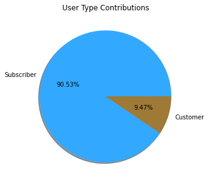

```python
# Show the percentage of each user type

show_pieplot(df,'user_type', [10,5], 'User Type Contributions')
```

> Most of the users are subscribers, which means that the subscription model used is effective.

### Self-Station Trips

The self-station trips are the trips when the user rent a bike from a station and then returning it back to the same station.

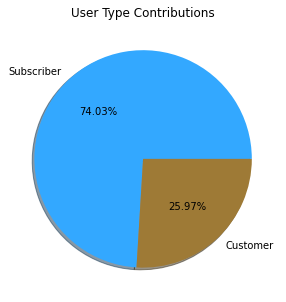

```python
# Starting and ending at the same station

show_pieplot(df[df.end_station_id == df.start_station_id],'user_type', [10,5], 'User Type Contributions')
```

> Most of the users who start and end their trips at the same station are subscribers not ad-hoc customers

### The Geographic Distribution of The Stations

```python
# Checking if the stations are used in both start and end trips

df[~df.end_station_id.isin(df.start_station_id)]
```

|  | duration_sec | start_time | end_time | start_station_id | start_station_name | start_station_latitude | start_station_longitude | end_station_id | end_station_name | end_station_latitude | ... | user_type | member_birth_year | member_gender | bike_share_for_all_trip | duration_in_mins | member_age | member_age_bucket | trip_distance | trip_start_day | trip_start_hour |
| --- | --- | --- | --- | --- | --- | --- | --- | --- | --- | --- | --- | --- | --- | --- | --- | --- | --- | --- | --- | --- | --- |

0 rows × 22 columns

> All the end stations are already used as start stations

```python
# Checking if the start stations are already used as end station
df[~df.start_station_id.isin(df.end_station_id)]
```

|  | duration_sec | start_time | end_time | start_station_id | start_station_name | start_station_latitude | start_station_longitude | end_station_id | end_station_name | end_station_latitude | ... | user_type | member_birth_year | member_gender | bike_share_for_all_trip | duration_in_mins | member_age | member_age_bucket | trip_distance | trip_start_day | trip_start_hour |
| --- | --- | --- | --- | --- | --- | --- | --- | --- | --- | --- | --- | --- | --- | --- | --- | --- | --- | --- | --- | --- | --- |

0 rows × 22 columns

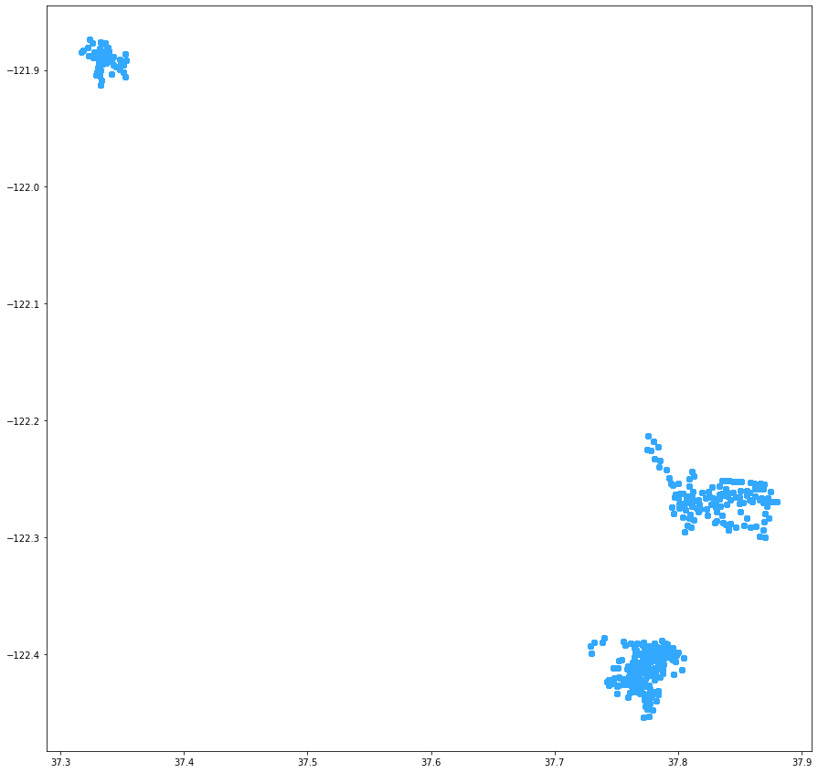

```python
# Displaying the distribution of the stations accross the city/state.
plt.figure(figsize=[15, 15])

# We can only use the stations are mentioned as start station to show the distribution of the stations.
plt.scatter(data=df, x='start_station_latitude', y='start_station_longitude', color=main_color)
plt.show()
```

> Some stations are clustered near to each other and some are located far, we should study and frequency of the trips distances.

### Contribution of Member Genders in The Total Number of Trips

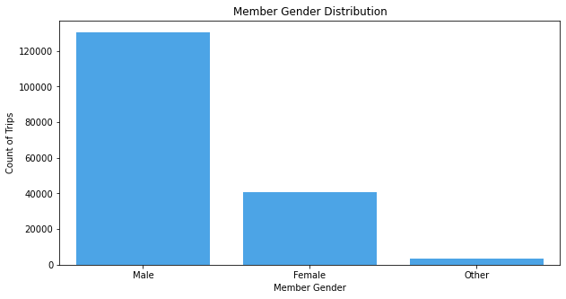

```python
# Members Gender Distribution
show_countplot(x='member_gender', figsize= [10,5], title='Member Gender Distribution', xtitle='Member Gender', ytitle='Count of Trips')
```

> Most of the bike riders is males.

### Distribution of Members Ages

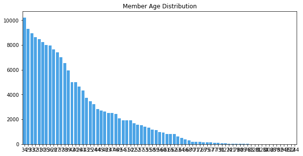

```python
# Members Age Distribution
show_countplot(x='member_age', figsize= [10,5], title='Member Age Distribution')
```

> Too many values appears on X-axis, it would be a good idea, to use a histogram with custom bins.

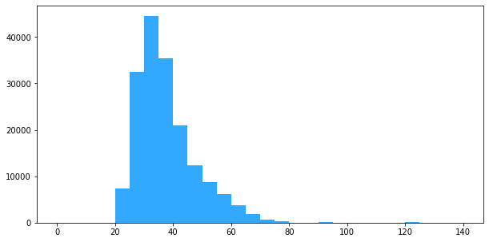

```python
## Analyze the distribution of the users' ages.
plt.figure(figsize=[10, 5])
# using bins with size of each is 5 years
bins = np.arange(0, df['member_age'].max(), 5)
plt.hist(df['member_age'], bins=bins, color= main_color)
plt.show()
```

### Distribution of Trip Duration

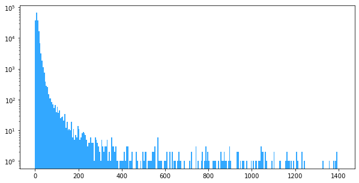

```python
# Show the distribution of the duration of the trips
plt.figure(figsize=[10, 5])

bins = np.arange(0, df['duration_in_mins'].max(), 5)
plt.hist(df['duration_in_mins'], bins=bins, color= main_color)
plt.yscale('log')
plt.show()
```

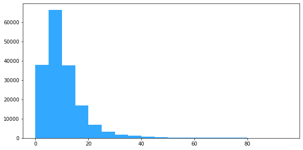

```python
# Show the distribution of the duration of the trips
plt.figure(figsize=[10, 5])

# too much data with low duration so we filter here to get the trips with duration in minutes less than 100 mins.
df_mins = df[df.duration_in_mins < 100]
bins = np.arange(0, df_mins['duration_in_mins'].max(), 5)
plt.hist(df_mins['duration_in_mins'], bins=bins, color= main_color)
plt.show()
```

### Distribution of Trip Distance

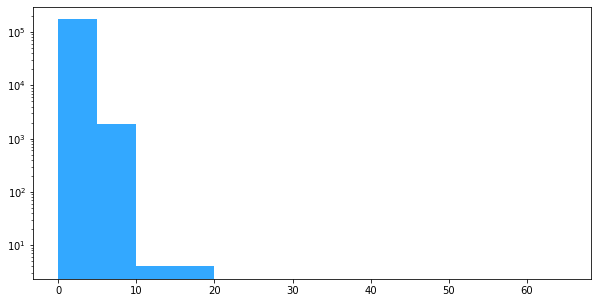

```python
# Show the distribution of the distance of the trips
plt.figure(figsize=[10, 5])

bins = np.arange(0, df['trip_distance'].max(), 5)
plt.hist(df['trip_distance'], bins=bins, color= main_color)
plt.yscale('log')
plt.show()
```

> Most of the trips have distance less than 5 distance unit, removing the other outliers will provide better understanding about the distance distribution.

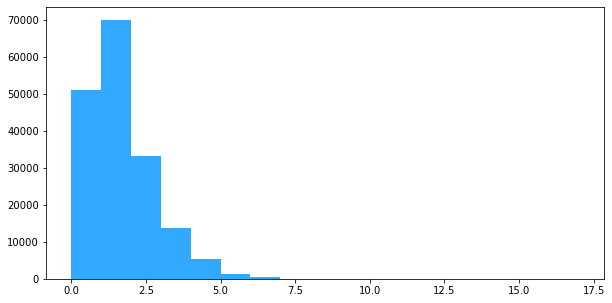

```python
# Show the distribution of the distance of the trips
plt.figure(figsize=[10, 5])

# too much data with low distance so we filter here to get the trips with distance in minutes less than 20 distance unit.
df_distance = df[df.trip_distance < 20]
bins = np.arange(0, df_distance['trip_distance'].max(), 1)
plt.hist(df_distance['trip_distance'], bins=bins, color= main_color)
plt.show()
```

### Number of Trips per Weekday

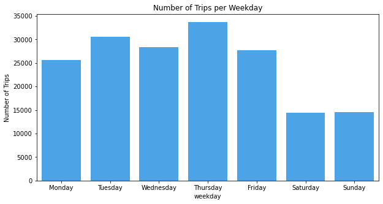

```python
# Get the count of trips per day over the all period

show_countplot(x='trip_start_day', title= 'Number of Trips per Weekday', xtitle='weekday', ytitle='Number of Trips', figsize=[10,5], order= weekdays_order)
```

> It seems that, through the weekend (Sunday & Saturday days) the number of the trips are the least which leads to a conclusion that most of the trips are used for work purposes.

### Number of Trips per Hour

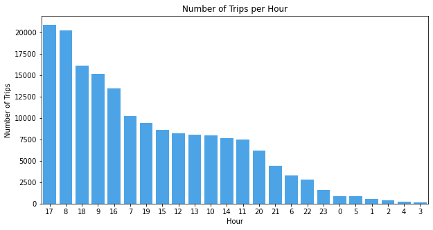

```python
# Show the count of the trips over the hours of day.

show_countplot(x='trip_start_hour', title= 'Number of Trips per Hour', xtitle='Hour', ytitle='Number of Trips', figsize=[10,5])
```

> Hours 5PM and 8AM are the peak hours. Which indicates that may be most of the users are employees and ride the bikes to their work place.

### Discuss the distribution(s) of your variable(s) of interest. Were there any unusual points? Did you need to perform any transformations?

  > *p.s* the data is filtered (to remove the outliers) in a dedicated data frame for each case in order not to affect the other features analysis.
- Grouping the *member age* data into bins of size 5 years showed a good insight about the age range of members of GoBike.

I used `logarithmic scale` for some distribution to view all the data and catch outliers.

## Bivariate Exploration

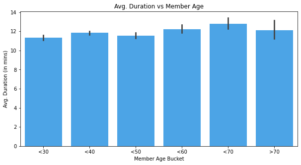

```python
# Show the relationship between the member age and the trip duration

plt.figure(figsize=[10,5])
plt.title('Avg. Duration vs Member Age')
sb.barplot(data=df, x= 'member_age_bucket', y='duration_in_mins', color=main_color)
plt.xlabel('Member Age Bucket')
plt.ylabel('Avg. Duration (in mins)');
plt.show()
```

> On average members between 60 and 70 years old took longer trips than other members.

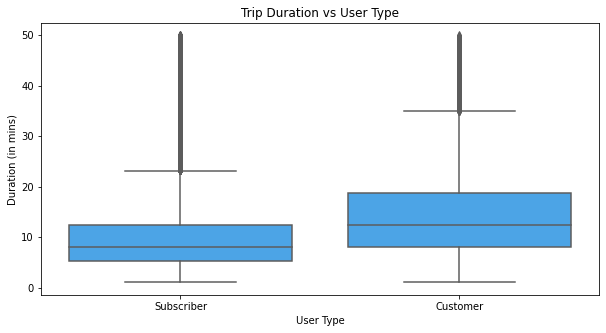

```python
# Show the relationship between user type and trip duration

plt.figure(figsize=[10,5])
plt.title('Trip Duration vs User Type')
# box plot the data after removing the outliers to get considerable insights
sb.boxplot(data=df[df.duration_in_mins < 50], x= 'user_type', y='duration_in_mins', color=main_color)
plt.xlabel('User Type')
plt.ylabel('Duration (in mins)');
plt.show()
```

> Ad-hoc users ride their bikes for longer duration than the subscriber. Maybe because the ad-hoc users make use of their bikes as they are renting them for shorter time unlike the subscribers who may rent the bikes for specific task.

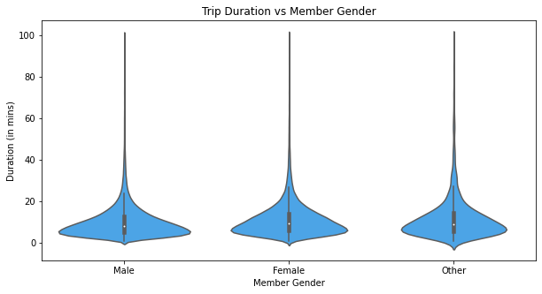

```python
# # Show the relationship between user type and trip duration

plt.figure(figsize=[10,5])
plt.title('Trip Duration vs Member Gender')
# box plot the data after removing the outliers to get considerable insights
sb.violinplot(data=df_mins, x= 'member_gender', y='duration_in_mins', color=main_color)
plt.xlabel('Member Gender')
plt.ylabel('Duration (in mins)');
plt.show()
```

> Member gender has no impact on the duration of the rental.

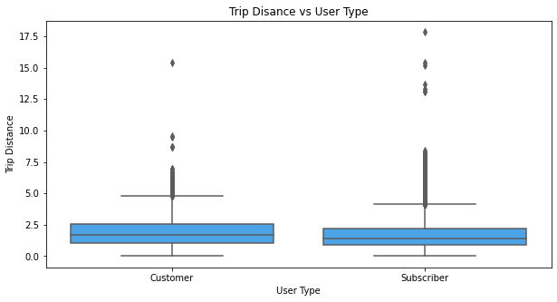

```python
# # Show the relationship between user type and trip distane

plt.figure(figsize=[10,5])
plt.title('Trip Disance vs User Type')
# box plot the data after removing the outliers to get considerable insights
sb.boxplot(data=df_distance, x= 'user_type', y='trip_distance', color=main_color)
plt.xlabel('User Type')
plt.ylabel('Trip Distance');
plt.show()
```

> Another finding supports that the ad-hoc users rent their bikes for slightly far ditances than the subscribers. Subscribers usually use their bikes from home to workplace.

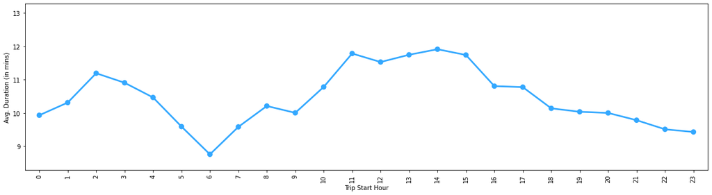

```python
# plot the point plot of the trip start hour
plt.figure(figsize=[20, 5])

sb.pointplot(data=df_mins, x='trip_start_hour', y='duration_in_mins', errwidth=0, color = main_color)
plt.xticks(rotation=90)
plt.xlabel('Trip Start Hour')
plt.ylabel('Avg. Duration (in mins)');
```

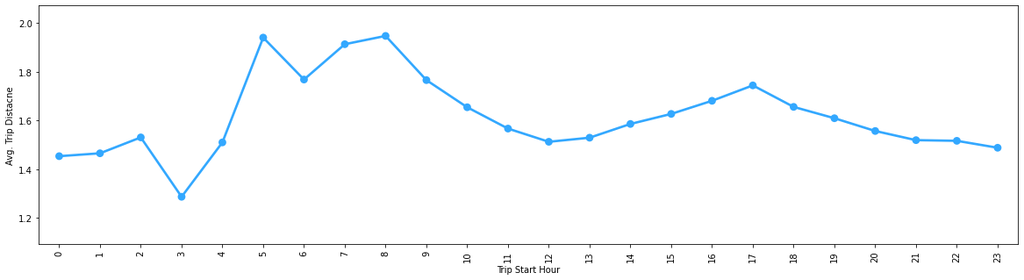

```python
# plot the point plot of the birth year
plt.figure(figsize=[20, 5])

sb.pointplot(data=df_distance, x='trip_start_hour', y='trip_distance', errwidth=0, color= main_color)
plt.xticks(rotation=90)
plt.xlabel('Trip Start Hour')
plt.ylabel('Avg. Trip Distacne');
```

> As found in the univariate analysis, at hours 8AM and 5PM the trip distance date have peak values.

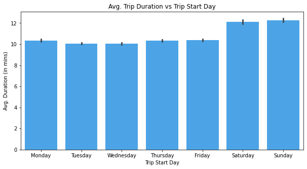

```python
# Show Avg. Trip Duration vs Trip Start Day

plt.figure(figsize=[10,5])
plt.title('Avg. Trip Duration vs Trip Start Day')
sb.barplot(data=df_mins, x= 'trip_start_day', y='duration_in_mins',  color=main_color, order = weekdays_order)
plt.xlabel('Trip Start Day')
plt.ylabel('Avg. Duration (in mins)');
plt.show()
```

> The average trip duration increases in the weekends.

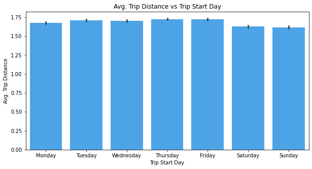

```python
# Show Avg. Trip Distance vs Trip Start Day

plt.figure(figsize=[10,5])
plt.title('Avg. Trip Distance vs Trip Start Day')
sb.barplot(data=df_distance, x= 'trip_start_day', y='trip_distance',  color=main_color, order = weekdays_order)
plt.xlabel('Trip Start Day')
plt.ylabel('Avg. Trip Distance')
plt.show()
```

> Although the avg. duration of the trips during the weekend is higher than the other days, the distance between the stations are the least. The users may spend fun time riding bikes during the weekends.

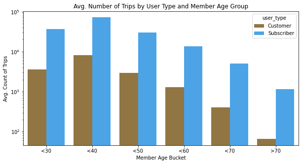

```python
# plot the trips count per the member age group and user type

plt.figure(figsize=[10,5])

sb.countplot(data=df, x='member_age_bucket',  hue='user_type', palette=[ '#9e7a36', main_color])

plt.title('Avg. Number of Trips by User Type and Member Age Group')
plt.xlabel('Member Age Bucket')
plt.ylabel('Avg. Count of Trips')
plt.yscale('log')
plt.show()
```

> Subscribers are older than the customers on average.

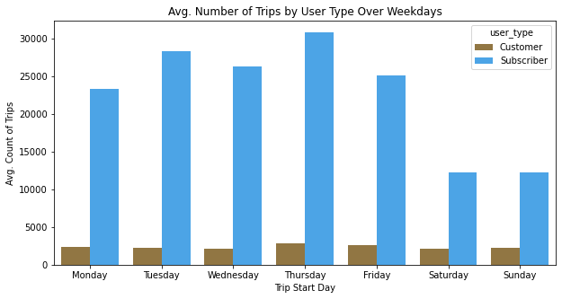

```python
# plot the trips count per the weekday and user type

plt.figure(figsize=[10,5])

sb.countplot(data=df, x='trip_start_day',  hue='user_type', palette=[ '#9e7a36', main_color], order = weekdays_order)

plt.title('Avg. Number of Trips by User Type Over Weekdays')
plt.xlabel('Trip Start Day')
plt.ylabel('Avg. Count of Trips')
plt.show()
```

> The subscribers have many rides more than the customer all the weekdays.

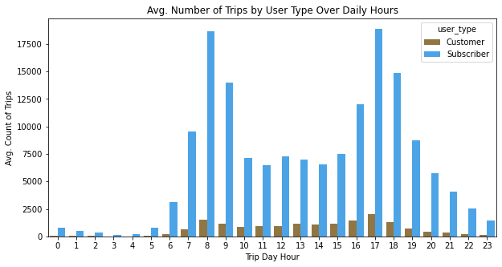

```python
# plot the trips count per the day hour and user type

plt.figure(figsize=[10,5])

sb.countplot(data=df, x='trip_start_hour',  hue='user_type', palette=[ '#9e7a36', main_color])

plt.title('Avg. Number of Trips by User Type Over Daily Hours')
plt.xlabel('Trip Day Hour')
plt.ylabel('Avg. Count of Trips')
plt.show()
```

> The two peaks we have at the hours 8AM and 5PM mainly because of the subscribers' rides.

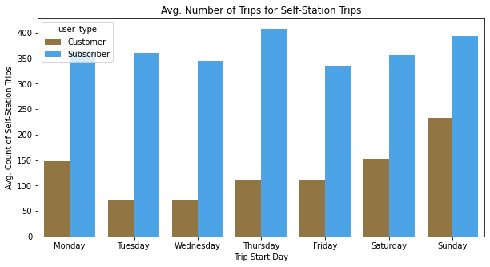

```python
# check for the trips that start and end in the station

plt.figure(figsize=[10,5])

df_self_station = df[df.end_station_id == df.start_station_id]

sb.countplot(data=df_self_station, x='trip_start_day',  hue='user_type', palette=[ '#9e7a36', main_color], order = weekdays_order)

plt.title('Avg. Number of Trips for Self-Station Trips')
plt.xlabel('Trip Start Day')
plt.ylabel('Avg. Count of Self-Station Trips')
plt.show()
```

> The self-station trips are frequent in weekends, espically for the ad-hoc users (customers).

### Did you observe any interesting relationships between the other features (not the main feature(s) of interest)?

- Interestingly, during weekends, the average trip duration is higher than the rest of the week. However, the trip distance in the weekend not the farthest.

## Multivariate Exploration

```python
from matplotlib import colors

def hist2dgrid(x, y, **kwargs):
    """ Quick hack for creating heat maps with seaborn's PairGrid. """
    palette = kwargs.pop('color')

    bins_x = 10
    bins_y = 10
    plt.hist2d(x, y, bins = [bins_x, bins_y], cmap = palette, cmin = 0.1,  norm = colors.LogNorm())
```

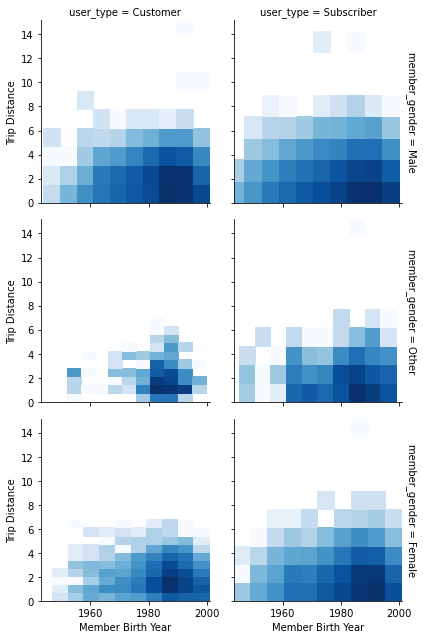

```python
# show the relationship between the user type, member gender, member birth year and the trip distance

# Excluding the outliers from the member birth year data
g = sb.FacetGrid(data = df_distance[(df_distance.member_birth_year > 1940) ], col = 'user_type', row='member_gender', margin_titles=True)
g.map(hist2dgrid, 'member_birth_year', 'trip_distance', color = 'Blues')
g.set_xlabels('Member Birth Year')
g.set_ylabels('Trip Distance')
plt.show()
```

> The trip distance usually between less than 6 distance unit. Most of the users ride for longer distances are the young male subscribers.

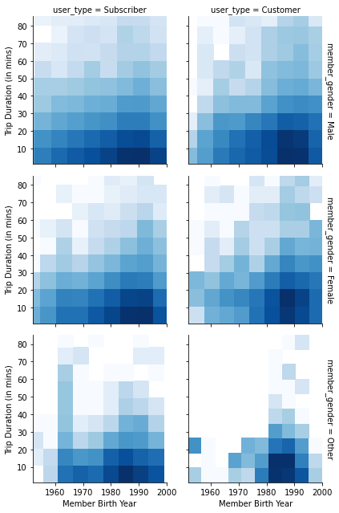

```python
# show the relationship between the user type, member gender, member birth year and the trip duration

# After removing the outliers from the member birth year and trip duration data
g = sb.FacetGrid(data = df_mins[(df_mins.member_birth_year > 1940) ], col = 'user_type', row='member_gender', margin_titles=True)
g.map(hist2dgrid, 'member_birth_year', 'duration_in_mins', color = 'Blues')
g.set_xlabels('Member Birth Year')
g.set_ylabels('Trip Duration (in mins)')
plt.show()
```

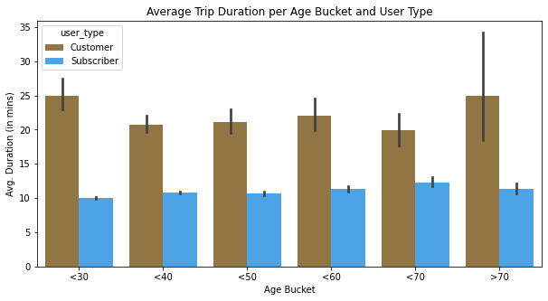

```python
# show relationship between the member age bucket and the user type against the trip duration


plt.figure(figsize=[10,5])

sb.barplot(data=df, x='member_age_bucket', y= 'duration_in_mins',  hue='user_type', palette=[ '#9e7a36', '#33A8FF'])

plt.title('Average Trip Duration per Age Bucket and User Type')
plt.xlabel('Age Bucket')
plt.ylabel('Avg. Duration (in mins)')
plt.show()
```

> - Customers' trips take longer than subscribers' for all the age groups.
> - Subscribers' trips take almost the same time (about 11 mins)

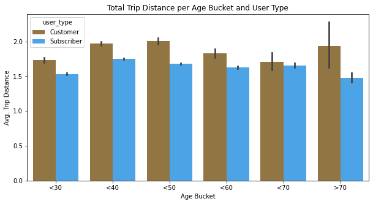

```python
# show relationship between the member age bucket and the user type against the trip distance

plt.figure(figsize=[10,5])

sb.barplot(data=df, x='member_age_bucket', y= 'trip_distance',  hue='user_type', palette=[ '#9e7a36','#33A8FF'])

plt.title('Total Trip Distance per Age Bucket and User Type')
plt.xlabel('Age Bucket')
plt.ylabel('Avg. Trip Distance')
plt.show()
```

> - The customers and subscribers from the age group (60-70) alomst have the same average trip distance.

```python
# show the relationship between the weekday, hour and a trip measure.
import math

def show_hourly_heatmap (df, dimension_name):
  i = 0
  plt.suptitle('Number of Rides Per Weekday and Hour')

  rows = 1 if math.ceil(len(df[dimension_name].unique())/4)  == 0 else math.ceil(len(df[dimension_name].unique())/4)
  fig,axs = plt.subplots(rows,4, figsize=( 25,5) )
  xvalue = 0
  for val in df[dimension_name].unique():
    if rows ==1 :
      xvalue=axs[i]
    else:
      xvalue = axs[i//4][i%4]
    sb.heatmap(df[df[dimension_name]==val].groupby(['trip_start_day', 'trip_start_hour']).size().reset_index(name='trips_count').pivot(index='trip_start_day', columns='trip_start_hour', values='trips_count'), cmap='Blues', ax=xvalue)
    xvalue.title.set_text(dimension_name +': '+val)
    i+=1



  fig.tight_layout(pad=3.0)

  fig.show()
```

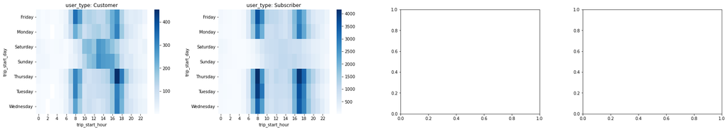

```python
show_hourly_heatmap(df, 'user_type')
```

> The customers are more active on weekends from 10:00AM to 4:00PM unlike the subscribers who are more active on other weekdays at 8:00AM and 5:00PM.

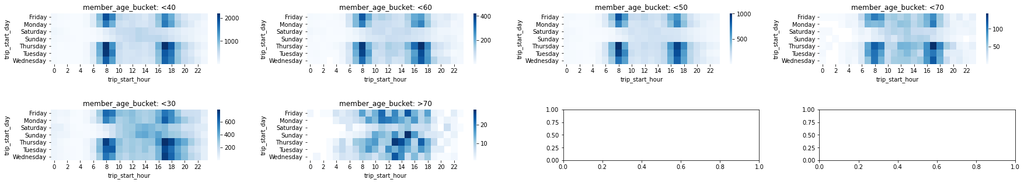

```python
show_hourly_heatmap(df, 'member_age_bucket')
```

> - For members younger than 60 years old, there are a pattern of daily and hourly riding routine, but for the members older than 60 years old, the pattern fades out, until for members older than 70 years old there is no pattern.

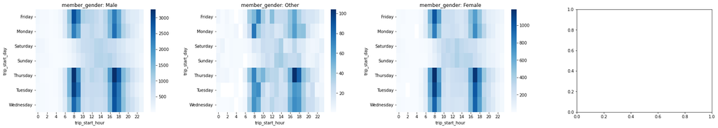

```python
show_hourly_heatmap(df, 'member_gender')
```

> - Female members are slightly more active than male members in weekends.

### Talk about some of the relationships you observed in this part of the investigation. Were there features that strengthened each other in terms of looking at your feature(s) of interest?

- The customers are more active on weekends from 10:00AM to 4:00PM unlike the subscribers who are more active on other weekdays at 8:00AM and 5:00PM.
- For members who are between 50 and 60 years old, there are a pattern of daily and hourly riding routine, but for the members older than 60 years old, the pattern fades out, until for members older than 70 years old there is no pattern.